# 基于 Barra 风格因子的产品超额收益归因分析

武宇翔

2026-06-19

# Introduction

## 一、研究背景与研究目的

在资产管理实践中，评价一只产品不仅要看绝对收益，更要看其相对业绩基准的超额表现，并进一步追问：超额收益来自稳定的选股与配置能力（alpha），还是来自对某些市场风格因子的暴露（beta）？若不能将二者区分，就难以对产品的风险来源与收益驱动形成清晰认识。

Barra 多因子模型将股票收益分解为若干可观测的**风格因子**（如规模、成长、动量、杠杆等），是业界常用的风险与归因工具。本报告以一只基金产品为研究对象，在中证 1000 指数基准下，利用 Barra 风格因子数据，对其超额收益进行探索性归因分析。研究目的可概括为：

1. **识别**与产品超额收益显著相关的 Barra 风格因子；
2. **检验**因子之间是否存在多重共线性，为回归建模筛选解释变量；
3. **估计**多元线性回归下各 Barra 因子的边际解释力；
4. **初步判断**样本期内产品超额更多体现为风格暴露，还是回归截距所代表的、无法被 Barra 因子线性解释的 alpha。

本研究属于**样本内、周频、线性**的探索性分析，旨在为后续更精细的持仓暴露归因或行业归因提供方向，不构成投资建议。

## 二、数据说明

本报告使用三类数据，经日期对齐后统一为**周频**样本（有效观测约 58 周）：

| 数据类型 | 来源 | 主要字段与处理 |
| --- | --- | --- |
| **产品净值** | `产品净值.xlsx` | 复权净值；按相邻交易日计算周收益率 |
| **业绩基准** | `K线导出_000852_日线数据.xlsx`（中证 1000，代码 000852） | 收盘价；计算指数周收益率 |
| **Barra 风格因子** | `Barra因子.xlsx` | 15 个风格因子的累积组合指数（首日 = 1）；转换为周收益率 |

# 第一部分：Barra 因子与产品超额收益的相关性分析

本部分为探索性分析，目的是初步筛选与产品超额收益相关的 Barra 风格因子，并识别因子之间的多重共线性，为后续多元回归归因做准备。

## 1.1 读取 Barra 因子并与超额收益对齐

Barra 数据为**日频因子组合累积指数**（首日 = 1），需转换为周收益率后再与产品超额收益计算相关系数。

## 1.2 因子指数转周收益率

## 1.3 产品超额收益与各 Barra 因子的相关系数

表 1：产品超额收益与各 Barra 因子周收益率的 Pearson 相关系数（* p<0.05, ** p<0.01）

| 因子中文名 | 因子 | 相关系数 | p值 | 显著性 |
| --- | --- | --- | --- | --- |
| 规模 | size | -0.5204 | 0.0000 | ** |
| 杠杆 | leverage | 0.3259 | 0.0125 | * |
| 中市值 | mid_cap | -0.2666 | 0.0431 | * |
| 长期反转 | long_term_reversal | 0.2560 | 0.0524 | . |
| 成长 | growth | -0.2344 | 0.0765 | . |
| 流动性 | liquidity | 0.2120 | 0.1102 |  |
| 盈利能力 | profitability | -0.1890 | 0.1552 |  |
| 盈利收益率 | earning_yield | -0.1772 | 0.1833 |  |
| 波动率 | volatility | -0.1041 | 0.4370 |  |
| 投资质量 | investment_quality | 0.0680 | 0.6118 |  |
| 股息 | dividend | -0.0627 | 0.6403 |  |
| 账面市值比 | book_to_price | 0.0280 | 0.8350 |  |
| 动量 | momentum | 0.0055 | 0.9676 |  |
| 盈利波动 | earning_variability | -0.0048 | 0.9714 |  |
| 贝塔 | beta | -0.0023 | 0.9861 |  |

## 1.4 Barra 因子之间的相关矩阵

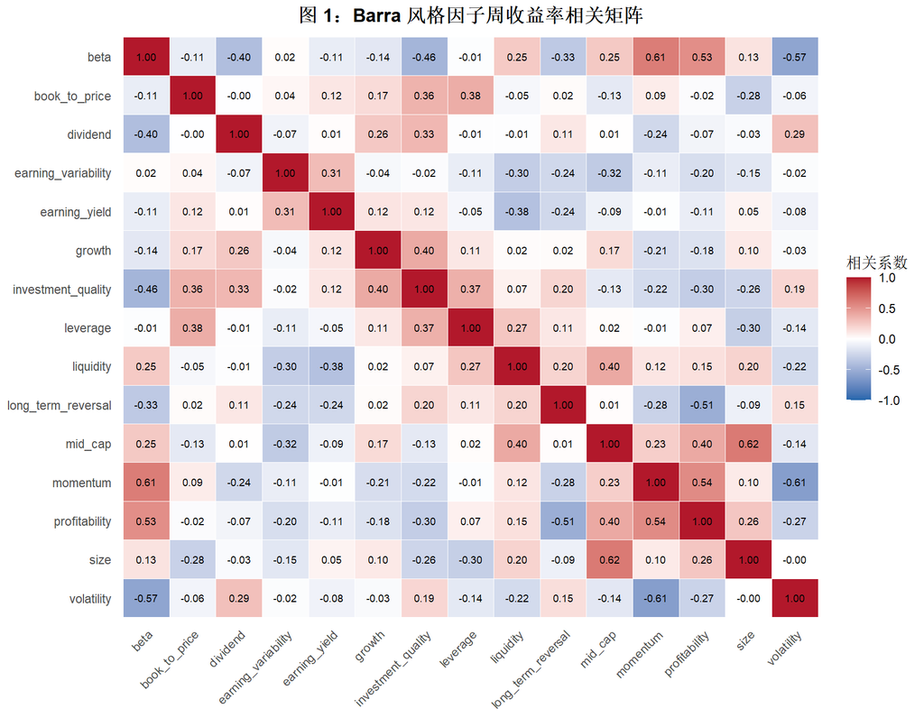

## 1.5 超额收益与主要因子的散点图

选取与超额收益相关性最强的 3 个因子作散点图，直观展示线性关系。

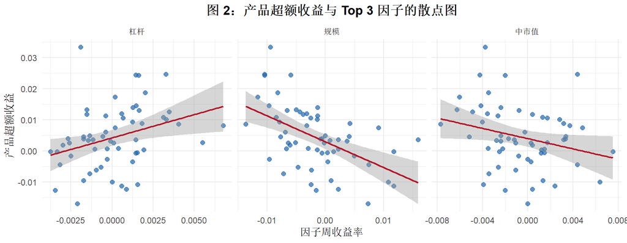

# 第二部分：多因子回归归因

本部分在第一部分筛选因子的基础上，对产品超额收益建立多元线性回归，估计各 Barra 风格因子的边际解释力，并判断超额收益更多来自风格暴露还是无法被因子解释的 alpha。

回归模型：

$$\text{超额收益}_t = \alpha + \sum_i \beta_i \cdot \text{因子}_t +
\varepsilon_t$$

## 2.1 产品累计超额收益走势

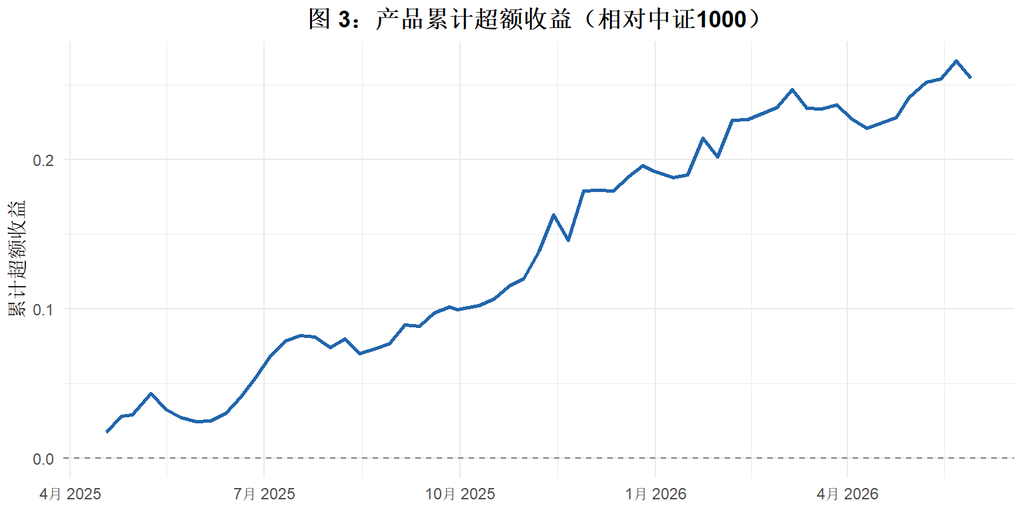

## 2.2 筛选因子多元回归

使用第一部分筛选出的因子（`筛选因子`）作为解释变量，估计各风格暴露及截距 alpha。

表 2：筛选因子多元回归（size + leverage + mid_cap + long_term_reversal + growth）

| 变量中文名 | 变量 | 估计值 | 标准误 | t值 | p值 | 显著性 |
| --- | --- | --- | --- | --- | --- | --- |
| 截距 (α) | (Intercept) | 0.0031 | 0.0011 | 2.7523 | 0.0081 | ** |
| 规模 | size | -0.7205 | 0.2413 | -2.9863 | 0.0043 | ** |
| 杠杆 | leverage | 0.8868 | 0.5432 | 1.6325 | 0.1086 |  |
| 中市值 | mid_cap | 0.1427 | 0.4483 | 0.3183 | 0.7515 |  |
| 长期反转 | long_term_reversal | 0.5769 | 0.3189 | 1.8091 | 0.0762 | . |
| 成长 | growth | -1.3043 | 0.6488 | -2.0103 | 0.0496 | * |

**p 值怎么读？** p 值表示「该变量对超额收益没有解释力」时，仍观察到当前结果的概率。**p 值越小，该因子在控制其他变量后，对超额收益的解释越重要**（越不像随机噪声）。一般 p < 0.05 认为显著，p < 0.01 认为高度显著。

**本表结论：**

- **截距 α**（p = 0.0081）：显著为正，说明扣掉所列风格因子后，产品仍有稳定的每周 alpha。
- **对超额解释最重要的风格因子**（p < 0.05，按 p 值从小到大）： 规模（β = -0.7205，p = 0.0043）； 成长（β = -1.3043，p = 0.0496）。
- **弱显著**（0.05 ≤ p < 0.10）：长期反转（p = 0.0762），仅供参考。
- **对超额解释不显著**（p ≥ 0.10）：杠杆（p = 0.1086）、中市值（p = 0.7515），在多元模型中可认为对样本期内超额波动**解释力有限**。

## 2.3 拟合值与残差：风格解释 vs alpha

表 3：超额收益归因分解

| 指标 | 数值 |
| --- | --- |
| 周均超额收益 | 0.0044 |
| 截距 α（周均无法被因子解释的部分） | 0.0031 |
| 风格拟合均值 | 0.0013 |
| 残差均值 | -0.0000 |

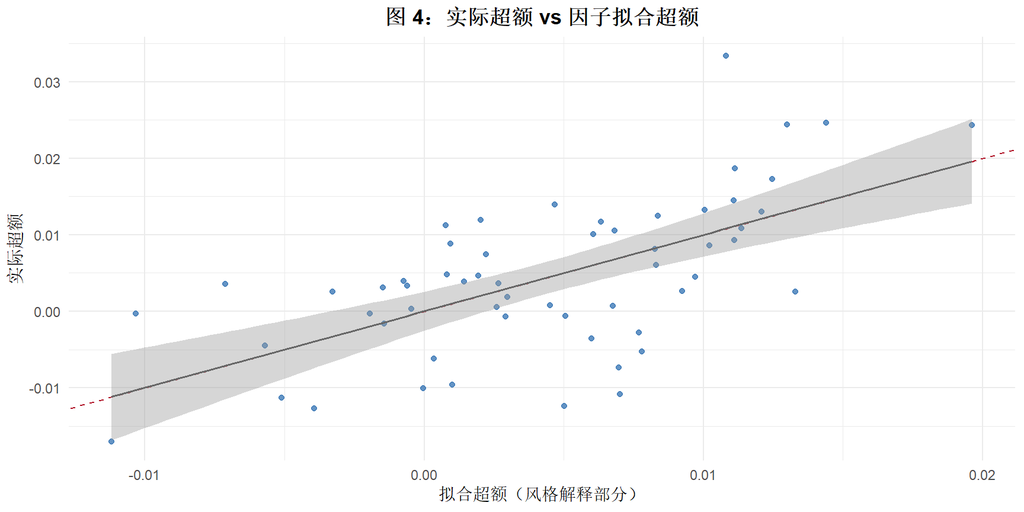

## 2.4 研究结论与局限性

### 研究结论

在 58 周样本内，筛选后的 Barra 因子可解释约 **39%** 的超额波动，调整 R² 约 **33%**。规模、成长暴露显著为负，截距 alpha 显著为正。综合来看，产品超额与**规模风格**关系最明显，但仍有约 **61%** 波动无法被所选 Barra 因子线性解释，需结合样本期短、归因口径简化等局限性谨慎解读。

### 产品涨跌与什么有关？（Barra 风格解读）

结合表 1 相关性与表 2 回归，样本期内产品超额（相对中证 1000）主要与以下因素有关：

[output not shown]

### 局限性

- 样本量有限（约 58 周），统计检验功效受限；
- 仅考察线性关系，未控制时变暴露与滞后效应；
- 超额收益为算术差，与 Barra 组合收益口径可能存在差异；
- 相关与回归结果均为样本内拟合，不代表未来持续有效。